# Statistical Inference

## Course Project

### Inference Exercies

Now in the second portion of the class, we’re going to analyze the ToothGrowth data in the R datasets package.

Let’s load the dataset first and take a look at it.

```r
data(ToothGrowth)
print(head(ToothGrowth))
```

```
##    len supp dose
## 1  4.2   VC  0.5
## 2 11.5   VC  0.5
## 3  7.3   VC  0.5
## 4  5.8   VC  0.5
## 5  6.4   VC  0.5
## 6 10.0   VC  0.5
```

There are three variables in the dataset:

[,1] len numeric Tooth length [,2] supp factor Supplement type (VC or OJ). [,3] dose numeric Dose in milligrams.

Let’s graph the data

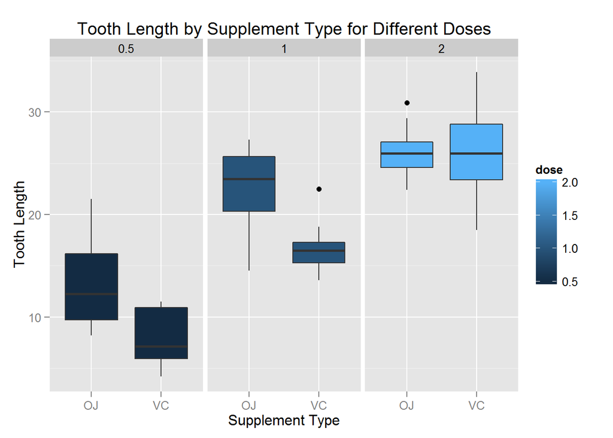

```r
library(ggplot2)
VC <- ToothGrowth[ToothGrowth$supp == "VC",]
OJ <- ToothGrowth[ToothGrowth$supp == "OJ",]

ggraph1 <- ggplot(ToothGrowth, aes(x=factor(supp), y=len, fill=dose))+
    geom_boxplot()+
    facet_grid(~dose)+
    labs(x="Supplement Type", y="Tooth Length",
         title = "Tooth Length by Supplement Type for Different Doses")
print(ggraph1)
```

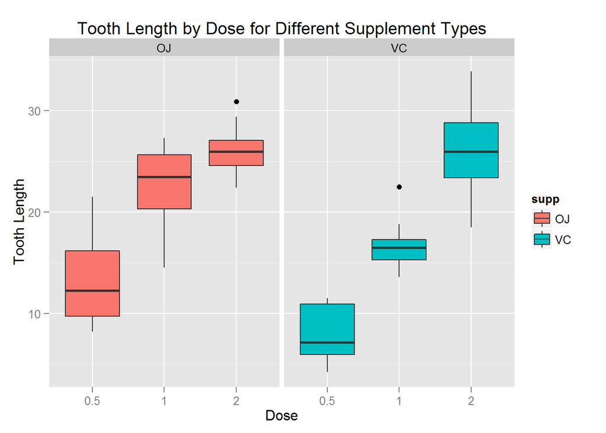

```r
ggraph2 <- ggplot(ToothGrowth, aes(x=factor(dose), y=len, fill=supp))+
    geom_boxplot()+
    facet_grid(~supp)+
    labs(x="Dose", y="Tooth Length",
         title = "Tooth Length by Dose for Different Supplement Types")
print(ggraph2)
```

```r
#By Dose
#Dose = 0.5
temp <- ToothGrowth[ToothGrowth$dose==0.5,]
ttest <- t.test(len ~ supp, temp, paired=FALSE, var.equal = FALSE, conf.level=0.95)
print(ttest)
```

```
##
##  Welch Two Sample t-test
##
## data:  len by supp
## t = 3.1697, df = 14.969, p-value = 0.006359
## alternative hypothesis: true difference in means is not equal to 0
## 95 percent confidence interval:
##  1.719057 8.780943
## sample estimates:
## mean in group OJ mean in group VC
##            13.23             7.98
```

As evident in the above, zero is not in the 95% confidence interval. Therefore, when the dose is 0.5, there is a significant difference in tooth length between the two delivery methods.

```r
#By Dose
#Dose = 0.5
temp <- ToothGrowth[ToothGrowth$dose==1.0,]
ttest <- t.test(len ~ supp, temp, paired=FALSE, var.equal = FALSE, conf.level=0.95)
print(ttest)
```

```
##
##  Welch Two Sample t-test
##
## data:  len by supp
## t = 4.0328, df = 15.358, p-value = 0.001038
## alternative hypothesis: true difference in means is not equal to 0
## 95 percent confidence interval:
##  2.802148 9.057852
## sample estimates:
## mean in group OJ mean in group VC
##            22.70            16.77
```

In this example, when the dose is 1.0, we also observe significant difference in tooth length between the two delivery methods.

```r
#By Dose
#Dose = 2.0
temp <- ToothGrowth[ToothGrowth$dose==2.0,]
ttest <- t.test(len ~ supp, temp, paired=FALSE, var.equal = FALSE, conf.level=0.95)
print(ttest)
```

```
##
##  Welch Two Sample t-test
##
## data:  len by supp
## t = -0.0461, df = 14.04, p-value = 0.9639
## alternative hypothesis: true difference in means is not equal to 0
## 95 percent confidence interval:
##  -3.79807  3.63807
## sample estimates:
## mean in group OJ mean in group VC
##            26.06            26.14
```

However, when the dose is 2.0, we find no significant difference in tooth length by the delivery method at the 95% confidence level. As we can see, zero falls in the 95% confidence interval.

Now we will test if there is any difference in tooth length by dose within the same delivery method.

```r
temp <- ToothGrowth[ToothGrowth$supp=="VC" & ToothGrowth$dose != 2.0,]
ttest <- t.test(len ~ dose, temp, paired=FALSE, var.equal = FALSE, conf.level=0.95)
print(ttest)
```

```
##
##  Welch Two Sample t-test
##
## data:  len by dose
## t = -7.4634, df = 17.862, p-value = 6.811e-07
## alternative hypothesis: true difference in means is not equal to 0
## 95 percent confidence interval:
##  -11.265712  -6.314288
## sample estimates:
## mean in group 0.5   mean in group 1
##              7.98             16.77
```

```r
temp <- ToothGrowth[ToothGrowth$supp=="VC" & ToothGrowth$dose != 0.5,]
ttest <- t.test(len ~ dose, temp, paired=FALSE, var.equal = FALSE, conf.level=0.95)
print(ttest)
```

```
##
##  Welch Two Sample t-test
##
## data:  len by dose
## t = -5.4698, df = 13.6, p-value = 9.156e-05
## alternative hypothesis: true difference in means is not equal to 0
## 95 percent confidence interval:
##  -13.054267  -5.685733
## sample estimates:
## mean in group 1 mean in group 2
##           16.77           26.14
```

The difference is also significant when the doses are 1.0 and 2.0

```r
temp <- ToothGrowth[ToothGrowth$supp=="OJ" & ToothGrowth$dose != 2.0,]
ttest <- t.test(len ~ dose, temp, paired=FALSE, var.equal = FALSE, conf.level=0.95)
print(ttest)
```

```
##
##  Welch Two Sample t-test
##
## data:  len by dose
## t = -5.0486, df = 17.698, p-value = 8.785e-05
## alternative hypothesis: true difference in means is not equal to 0
## 95 percent confidence interval:
##  -13.415634  -5.524366
## sample estimates:
## mean in group 0.5   mean in group 1
##             13.23             22.70
```

The difference in tooth length when the delivery method is OJ is also significant for doses 0.5 and 1.0 at 95% confidence level.

```r
temp <- ToothGrowth[ToothGrowth$supp=="OJ" & ToothGrowth$dose != 0.5,]
ttest <- t.test(len ~ dose, temp, paired=FALSE, var.equal = FALSE, conf.level=0.95)
print(ttest)
```

```
##
##  Welch Two Sample t-test
##
## data:  len by dose
## t = -2.2478, df = 15.842, p-value = 0.0392
## alternative hypothesis: true difference in means is not equal to 0
## 95 percent confidence interval:
##  -6.5314425 -0.1885575
## sample estimates:
## mean in group 1 mean in group 2
##           22.70           26.06
```

The difference is also significant for the doses 1.0 and 2.0.